# The Ladder of Causation

Fernando Miguez

1/18/2021

# The beginning

The chapter starts with the story of Adam and Eve in Genesis. The author says:

> God asked “what” and they answered “why”. God asked for the facts, and they replied with explanations

Some take-aways:

1. The world is not made up of dry facts (data). These facts are glued together by cause-effect relationships
2. Causal explanations, not dry facts, make the bulk of our knowledge
3. The transition from processors of data to makers of explanations was not gradual; it was a leap that required an external push from an uncommon fruit. No machine can derive explanations from raw data. It needs a push.

The first causal diagram in the book is about mammoth hunting and the factors that go into it. He calls this a “causal inference engine”.

> A causal learner must master at least three distinct levels of cognitive ability: seeing, doing and imagining

> I can prove mathematically that the three levels differ fundamentally

# Ladder of Causation

This seems fairly intuitive. Should it be called the “Ladder of Reasoning”

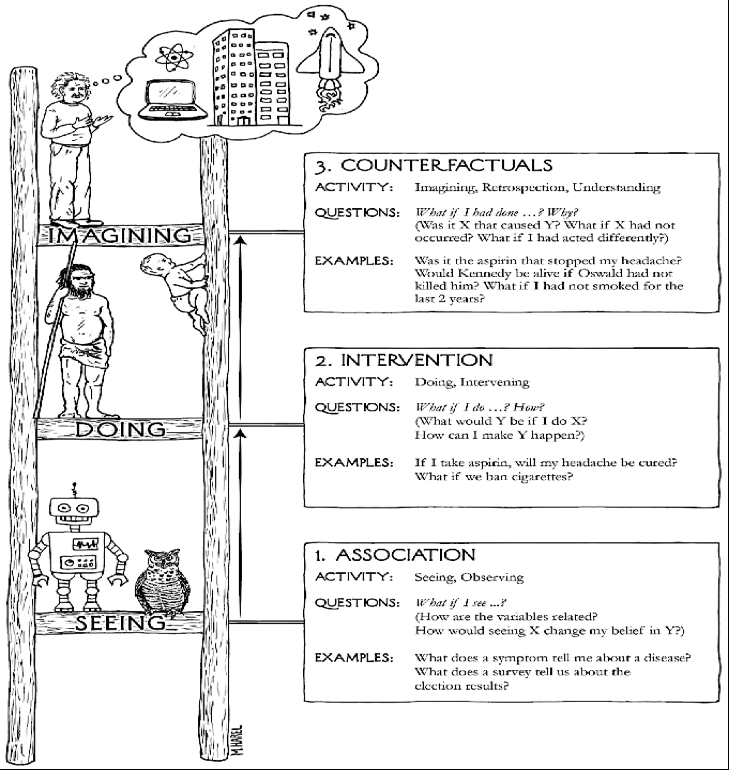

Ladder-of-Causation

### Toothpaste example

$$P(floss \; | \; toothpaste)$$

The author asks: “What if we double the price?” and points out that this is a difficult question for a number of reasons:

- That price might have never been seen before
- If the price had been twice as much in the past many other factors might have been different too
- We are now dealing with a deliberate intervention, not a passive observation

> A sufficiently strong and accurate causal model can allow us to use rung-one (observational) data to answer rung-two (interventional) queries.

Without the causal model, you cannot do this. Again he reminds us that:

$$P(floss \; | \; toothpaste) \neq P(floss \; | \; do(toothpaste))$$

The Lion Man of Stadel Cave is an example of human imagination. A creation which breaks the rules of what is seen in nature. A counterfactual.

### Firing squad example

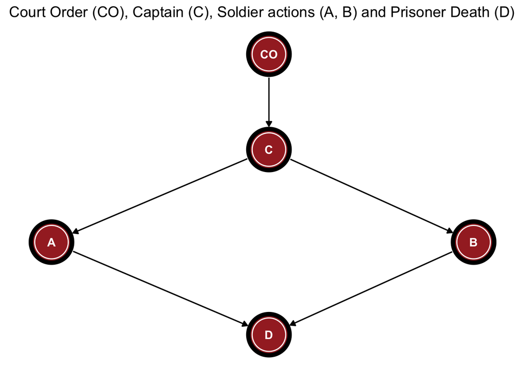

> When you make an event happen, remove all arrows that point to that event and continue the analysis ordinary logic, as if the arrows had never been there

> Making an event happen means that you emancipate it from all other influences and subject it to one and onle one influence – that which enforces its happening

### Vaccination example

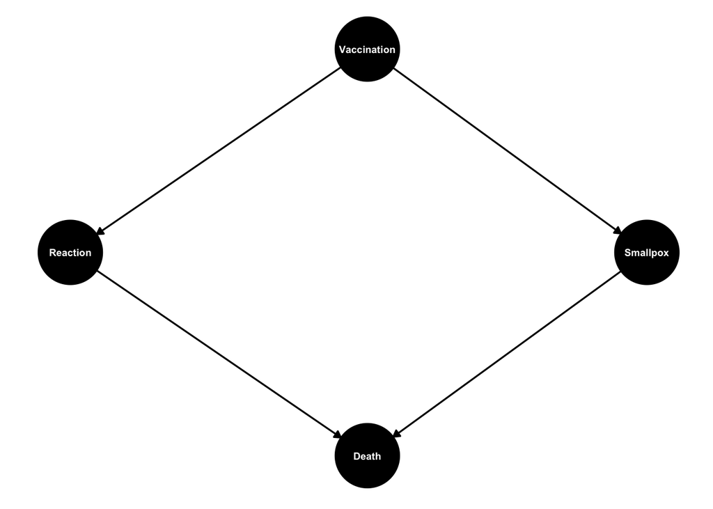

> Very often the structure of the diagram itself enables us to estimate all sorts of causal and counterfactual relationships: simple or complicate, deterministic or probabilistic, linear or nonlinear.

The chapter finished with a discussion of probabilities and causation and the role that the *do* operator plays. Again we see that there is a fundamental distinction between these two statements:

$$P(Y \; | X) > P(Y)$$

$$P(Y \; | do(X)) > P(Y)$$